# Analiza wieku studentow i wynikow na egzaminie

Doskonalenie umiejętności w środowisku RStudio

Autor

Afiliacja

Jakub Żołdak

Super Sigmy

Opublikowano

23 maja 2025

# Wstęp

Celem tego projektu jest zbadanie różnych parametrów studentów i tego jak rzutają one na wyniki na egzaminie. W szczególności przeanalizujemy dane dotyczące ich nawyków związanych ze stylem życia, takich jak liczba godzin spędzonych na nauce, korzystanie z mediów społecznościowych, jakość snu oraz poziom aktywności fizycznej. Dzięki danym zawartym w pliku `student_habits_performance.csv` oraz narzędziom dostępnym w RStudio, przeprowadzimy szczegółową analizę statystyczną, pozwalającą określić wpływ tych czynników na wyniki egzaminacyjne. Wyniki badań mogą dostarczyć istotnych wskazówek dotyczących efektywnego zarządzania czasem i metod nauki sprzyjających sukcesowi akademickiemu.

## Wczytwyanie i poprawienie typów danych

Będziemy dokonywać analizy na podstawie pliku `student_habits_performance.csv` który można pobrać z [kaggle.com](https://www.kaggle.com/datasets/jayaantanaath/student-habits-vs-academic-performance) (Kaggle to popularna platforma dla entuzjastów data science w której użytkownicy mogą między innymi pobierać zestawy danych).

**Kod**

```r
library(tidyverse)
library(ggplot2)
students <- read.csv(file = './student_habits_performance.csv')
```

Dobrą praktyką jest rozpoczęcie analizy od podstawowych statystyk opisowych. Pozwala to na szybką inspekcję nieprawidłowości w danych oraz identyfikację potencjalnych błędów, takich jak brakujące wartości czy nietypowe obserwacje.

Na początku sprawdzimy czy nasz zbiór danych jest całkowity (nie ma w nim żadnych `NA`) oraz czy kolumny mają odpowiedni typ zmiennych.

**Kod**

```r
glimpse(students)
```

```
Rows: 1,000
Columns: 16
$ student_id                    <chr> "S1000", "S1001", "S1002", "S1003", "S10…
$ age                           <int> 23, 20, 21, 23, 19, 24, 21, 21, 23, 18, …
$ gender                        <chr> "Female", "Female", "Male", "Female", "F…
$ study_hours_per_day           <dbl> 0.0, 6.9, 1.4, 1.0, 5.0, 7.2, 5.6, 4.3, …
$ social_media_hours            <dbl> 1.2, 2.8, 3.1, 3.9, 4.4, 1.3, 1.5, 1.0, …
$ netflix_hours                 <dbl> 1.1, 2.3, 1.3, 1.0, 0.5, 0.0, 1.4, 2.0, …
$ part_time_job                 <chr> "No", "No", "No", "No", "No", "No", "Yes…
$ attendance_percentage         <dbl> 85.0, 97.3, 94.8, 71.0, 90.9, 82.9, 85.8…
$ sleep_hours                   <dbl> 8.0, 4.6, 8.0, 9.2, 4.9, 7.4, 6.5, 4.6, …
$ diet_quality                  <chr> "Fair", "Good", "Poor", "Poor", "Fair", …
$ exercise_frequency            <int> 6, 6, 1, 4, 3, 1, 2, 0, 3, 5, 1, 2, 1, 4…
$ parental_education_level      <chr> "Master", "High School", "High School", …
$ internet_quality              <chr> "Average", "Average", "Poor", "Good", "G…
$ mental_health_rating          <int> 8, 8, 1, 1, 1, 4, 4, 8, 1, 10, 3, 1, 9, …
$ extracurricular_participation <chr> "Yes", "No", "No", "Yes", "No", "No", "N…
$ exam_score                    <dbl> 56.2, 100.0, 34.3, 26.8, 66.4, 100.0, 89…
```

**Kod**

```r
colSums(is.na(students))
```

```
                   student_id                           age
                            0                             0
                       gender           study_hours_per_day
                            0                             0
           social_media_hours                 netflix_hours
                            0                             0
                part_time_job         attendance_percentage
                            0                             0
                  sleep_hours                  diet_quality
                            0                             0
           exercise_frequency      parental_education_level
                            0                             0
             internet_quality          mental_health_rating
                            0                             0
extracurricular_participation                    exam_score
                            0                             0
```

Zauważmy, że niektóre kolumny takie jak `part_time_job` czy `internet_quality` są rodzaju `character` mimo, że wygodniej by było gdyby były rodzaju `factor`. Użyjemy do tego funkcji `mutate()`:

**Kod**

```r
students %>%
  mutate(gender = as.factor(gender),
         part_time_job = as.factor(part_time_job),
         diet_quality = as.factor(diet_quality),
         parental_education_level = as.factor(parental_education_level),
         internet_quality = as.factor(internet_quality),
         extracurricular_participation = as.factor(extracurricular_participation)) -> students
glimpse(students)
```

```
Rows: 1,000
Columns: 16
$ student_id                    <chr> "S1000", "S1001", "S1002", "S1003", "S10…
$ age                           <int> 23, 20, 21, 23, 19, 24, 21, 21, 23, 18, …
$ gender                        <fct> Female, Female, Male, Female, Female, Ma…
$ study_hours_per_day           <dbl> 0.0, 6.9, 1.4, 1.0, 5.0, 7.2, 5.6, 4.3, …
$ social_media_hours            <dbl> 1.2, 2.8, 3.1, 3.9, 4.4, 1.3, 1.5, 1.0, …
$ netflix_hours                 <dbl> 1.1, 2.3, 1.3, 1.0, 0.5, 0.0, 1.4, 2.0, …
$ part_time_job                 <fct> No, No, No, No, No, No, Yes, Yes, No, No…
$ attendance_percentage         <dbl> 85.0, 97.3, 94.8, 71.0, 90.9, 82.9, 85.8…
$ sleep_hours                   <dbl> 8.0, 4.6, 8.0, 9.2, 4.9, 7.4, 6.5, 4.6, …
$ diet_quality                  <fct> Fair, Good, Poor, Poor, Fair, Fair, Good…
$ exercise_frequency            <int> 6, 6, 1, 4, 3, 1, 2, 0, 3, 5, 1, 2, 1, 4…
$ parental_education_level      <fct> Master, High School, High School, Master…
$ internet_quality              <fct> Average, Average, Poor, Good, Good, Aver…
$ mental_health_rating          <int> 8, 8, 1, 1, 1, 4, 4, 8, 1, 10, 3, 1, 9, …
$ extracurricular_participation <fct> Yes, No, No, Yes, No, No, No, No, No, Ye…
$ exam_score                    <dbl> 56.2, 100.0, 34.3, 26.8, 66.4, 100.0, 89…
```

Zamiana rodzaju zmiennej na `factor` ułatwi nam późniejszą analizę tych danych i wizualizację wyników.

**Kod**

```r
apply(students, MARGIN = 2, FUN = summary)
```

```
       student_id  age         gender      study_hours_per_day
Length "1000"      "1000"      "1000"      "1000"
Class  "character" "character" "character" "character"
Mode   "character" "character" "character" "character"
       social_media_hours netflix_hours part_time_job attendance_percentage
Length "1000"             "1000"        "1000"        "1000"
Class  "character"        "character"   "character"   "character"
Mode   "character"        "character"   "character"   "character"
       sleep_hours diet_quality exercise_frequency parental_education_level
Length "1000"      "1000"       "1000"             "1000"
Class  "character" "character"  "character"        "character"
Mode   "character" "character"  "character"        "character"
       internet_quality mental_health_rating extracurricular_participation
Length "1000"           "1000"               "1000"
Class  "character"      "character"          "character"
Mode   "character"      "character"          "character"
       exam_score
Length "1000"
Class  "character"
Mode   "character"
```

# Analiza zależności

Analiza zależności pozwoli nam zidentyfikować wpływ różnych czynników na wyniki egzaminacyjne studentów. Skupimy się na wykryciu istotnych korelacji między zmiennymi, co umożliwi lepsze zrozumienie mechanizmów wpływających na lepszy `exam_score`.

## Analiza macierzy koleracji

Macierz korelacji to tabela, która przedstawia współczynniki korelacji między różnymi zmiennymi w zbiorze danych. Pozwala ona zidentyfikować zależności między cechami, np. czy większa liczba godzin nauki wiąże się z lepszymi wynikami na egzaminie. Wartości korelacji mieszczą się w zakresie od -1 do 1, gdzie:

- 1 oznacza **silną dodatnią zależność**,
- -1 oznacza **silną ujemną zależność**,
- 0 oznacza **brak zależności**.

**Kod**

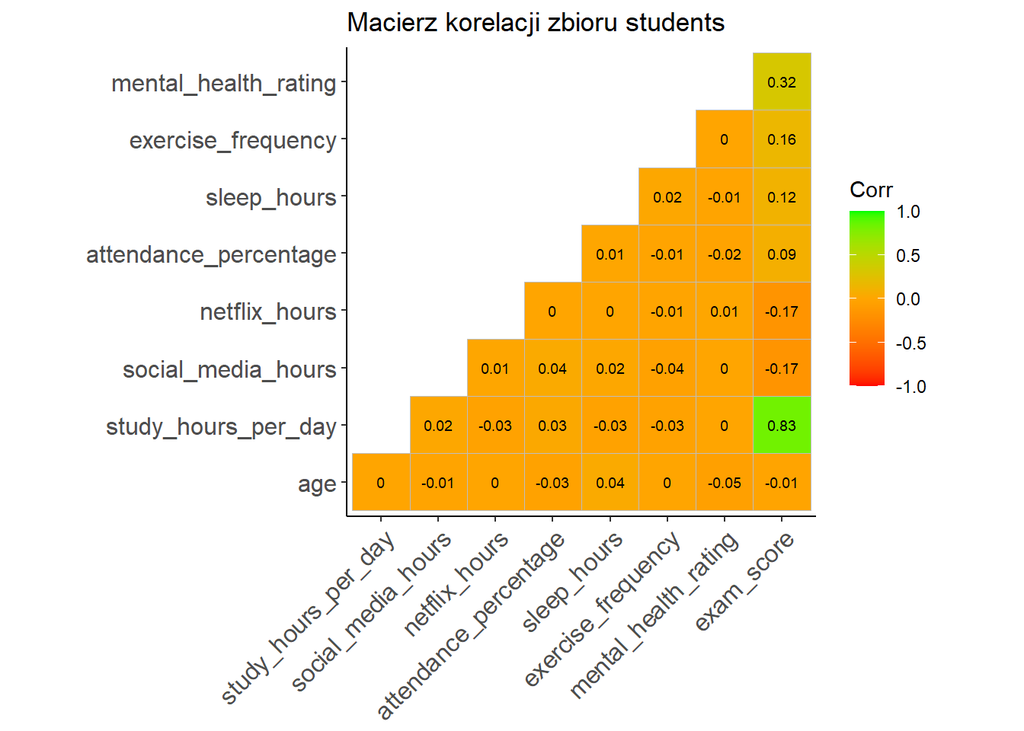

```r
students %>%
  select_if(is.numeric)%>%
  cor()%>%
  ggcorrplot::ggcorrplot(type = 'lower',
                         method = 'square',
                         lab = T,
                         lab_size = 2.5,
                         colors = c("red","orange","green"),
                         title = "Macierz korelacji zbioru students",
                         ggtheme = ggplot2::theme_classic())
```

Na macierzy koleracji dotyczącej naszego zbioru danych `students` możemy zauważyć, że :

- Silna korelacja ( 0.83 między `study_hours_per_day` a `exam_score`) sugeruje, że im więcej czasu student poświęca na naukę, tym lepsze osiąga wyniki.
- Słaba korelacja ( -0.17 między `netflix_hours` a `exam_score`) może wskazywać, że zwiększona ilość czasu spędzanego na rozrywce wpływa negatywnie na wyniki egzaminacyjne.

Zobaczmy czy te koleracje faktycznie wychodzą podczas wizualizacji danych

## Czy istnieje korelacja między liczbą godzin nauki dziennie (`study_hours_per_day`) a wynikiem egzaminu (`exam_score`)

W naszej macierzy koleracji wartość koleracji między `study_hours_per_day` a `exam_score` wynosił 0.83. Zobaczymy czy faktycznie tak jest. Sprawdźimy to za pomocą wykresu puntkowego z pakietu `ggplot2`:

**Kod**

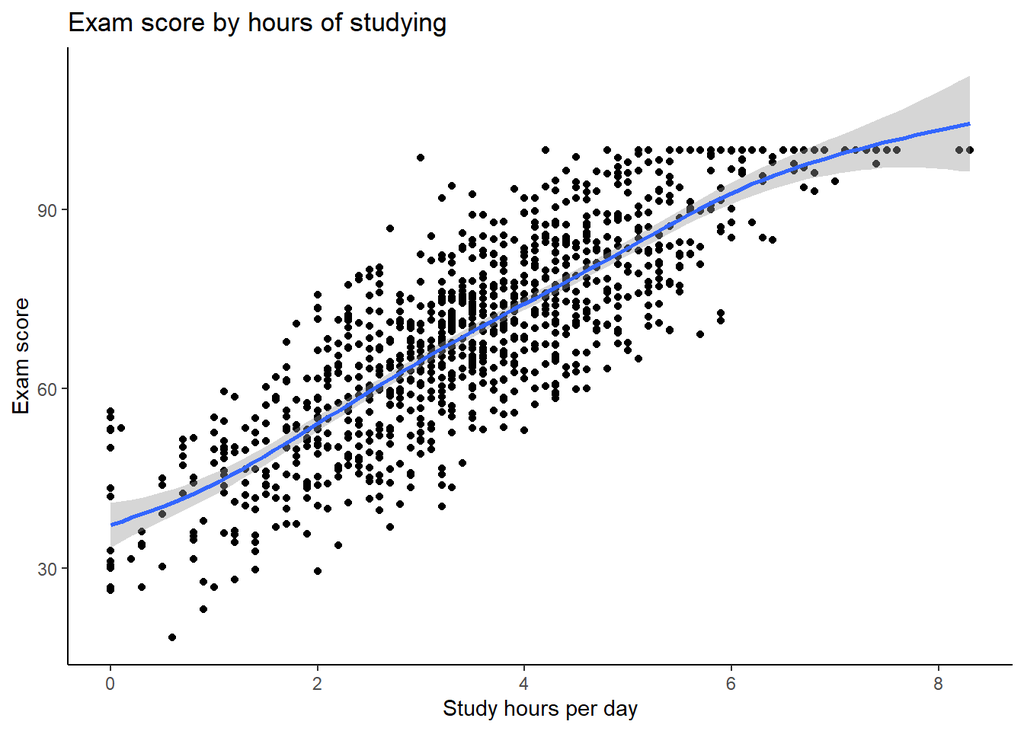

```r
ggplot(students,aes(x = study_hours_per_day, y = exam_score,))+
  geom_point()+
  geom_smooth()+
  theme_classic()+
  labs(x = "Study hours per day", y = "Exam score", title = "Exam score by hours of studying")
```

Na podstawie powyższego wykresu punktowego i macierzy koleracji przedstawionej powyżej, jednoznacznie stwierdzamy, że **im więcej nauki, tym lepsze wyniki**

## Czy istnieje koleracja między ilością czasu spędzonym na internecie (`netflix_hours` + `social_media_hours`) a wynikiem egzaminiu (`exam_score`)

W naszej macierzy koleracji wartość koleracji między `netflix_hours` a `exam_score` wynosił -0.17.

Taki sam wynik (-0.17) jest między `social_media_hours` a `exam_score`, dlatego możemy postawić tezę “Czy istenieje koleracja między czasem spędzonym na internecie a wynikiem egzaminu”.

Najpierw musimy utworzyć nową kolumnę (`internet_hours_per_day`) która będzie sumą `netflix_hours` i `social_media_hours`. Następnie podzielimy tą kolumnę na następujące poziomy:

- `Low` - niska ilość czasu spędzona w internecie,
- `Normal` - normalna ilość czasu spędzona w internecie,
- `High` - wysoka ilość czasu spędzona w internoście,
- `Very High` - podchodząca pod uzależnienie, ilość czasu spędzona w internecie,

**Kod**

```r
students <- students %>%
  mutate(internet_hours_per_day = social_media_hours + netflix_hours)

summary(students$internet_hours_per_day)
```

```
   Min. 1st Qu.  Median    Mean 3rd Qu.    Max.
  0.200   3.300   4.400   4.325   5.400  10.100
```

**Kod**

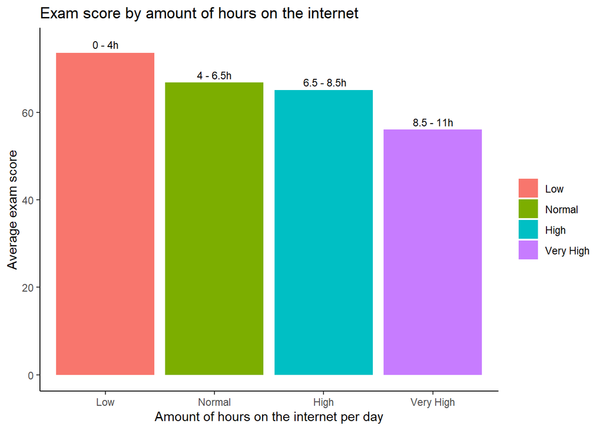

```r
students$internet_hours_per_day <- cut(students$internet_hours_per_day, breaks = c(0,4,6.5,8.5,11), labels = c("Low","Normal","High","Very High"), include.lowest = T)

students_score_by_internet <- students %>%
  group_by(internet_hours_per_day) %>%
  summarise(avg_exam = mean(exam_score))

ggplot(students_score_by_internet,aes(x = internet_hours_per_day, y = avg_exam, fill = internet_hours_per_day))+
  geom_col()+
  theme_classic()+
  labs(title = "Exam score by amount of hours on the internet", x = "Amount of hours on the internet per day", y = "Average exam score", fill = "")+
   annotate("text", x = 1, y = max(students_score_by_internet$avg_exam) + 2, label = "0 - 4h", size = 3, color = "black") +
  annotate("text", x = 2, y = max(students_score_by_internet$avg_exam) -5, label = "4 - 6.5h", size = 3, color = "black") +
  annotate("text", x = 3, y = max(students_score_by_internet$avg_exam) - 6.6, label = " 6.5 - 8.5h", size = 3, color = "black") +
  annotate("text", x = 4, y = max(students_score_by_internet$avg_exam) - 15.8, label = "8.5 - 11h", size = 3, color = "black")
```

**Kod**

```r
## tutaj funkcje annotate() znalazlem za pomoca copilota i bardzo fajne rozwiazanie
```

Na powyższym wykresie słupkowym widzimy zależność między ilością czasu spędzonym na internecie `internet_hours_per_day` a uśrednionym wyniku na egzaminie `avg_exam`. Możemy stwierdzić, że osoby które spędzają **mniej** niż 4 godziny dziennie na internecie, mają **wyższe** wyniki na egzaminie, niż osoby które spędzają na internecie więcej niż 4 godziny dziennie.

## Czy kobiety mają lepsze oceny od mężczyzn?

Często między mężczyznami a kobietami istnieje różnica jeżeli chodzi o osiągnięcia w nauce, czy tak samo będzie w tym przypadku?

Poniżej mamy dwa wykresy jeden słupkowy (`geom_col()`), a drugi liniowy (`geom_density()`).

**Kod**

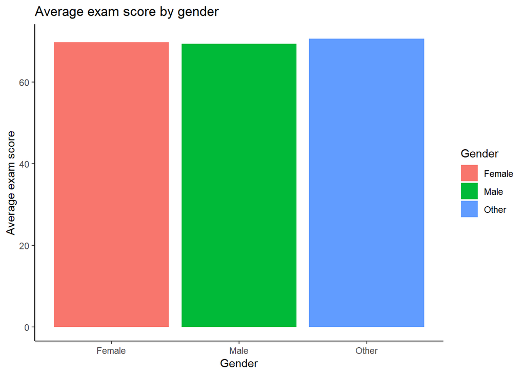

```r
scores_by_gender <- students %>%
  group_by(gender) %>%
  summarise(avg_grade = mean(exam_score))

ggplot(scores_by_gender, aes(x = gender, y = avg_grade, fill = gender)) +
  geom_col() +
  labs(title = "Average exam score by gender",
       x = "Gender",
       y = "Average exam score",
       fill = "Gender") +
  theme_classic()
```

**Kod**

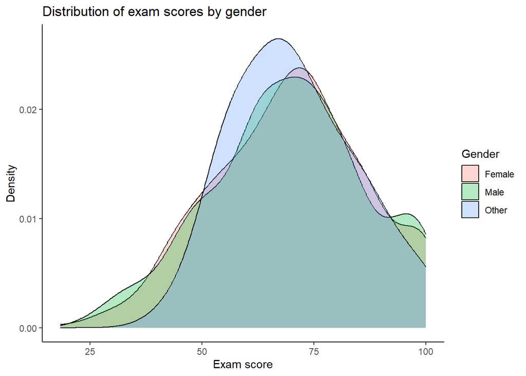

```r
ggplot(students)+
  geom_density(aes(x = exam_score, fill = gender), alpha = 0.3)+
  theme_classic()+
  labs(title = "Distribution of exam scores by gender",x = "Exam score", y = "Density", fill = "Gender")
```

Na podstawie wykresów widzimy, że nie istnieje koleracja między płcią a wynikiem na egzaminie.

## Czy osoby spędzające więcej czasu w mediach społecznościowych (`social_media_hours`) mają gorsze zdrowie psychiczne

Sprawdzmy czy osoby które spędzają więcej czasu w mediach społecznościowych `social_media_hours` mają gorsze zdrowie psychiczne `mental_health_rating` niż osoby które spędzają mniej czasu w mediach społecznościowych.

**Kod**

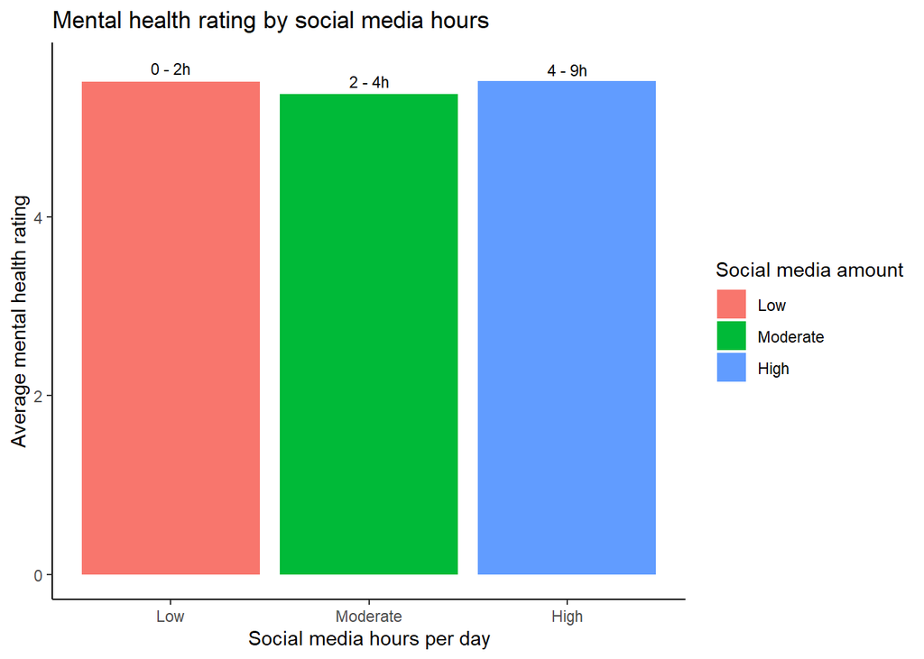

```r
students$social_media_class <-  cut(students$social_media_hours, breaks = c(0,2,4,9), labels = c('Low',
                                                                                                'Moderate',
                                                                                                'High'), include.lowest = T)

mh_means <- students %>%
  group_by(social_media_class) %>%
  summarize(mean_mental_health_rating = mean(mental_health_rating))


ggplot(mh_means)+
  geom_col(aes(x = social_media_class, y = mean_mental_health_rating, fill = social_media_class))+
  theme_classic()+
  labs(title = "Mental health rating by social media hours", x = "Social media hours per day", y = "Average mental health rating", fill = "Social media amount")+
annotate("text", x = 1, y = max(mh_means$mean_mental_health_rating) +0.15, label = "0 - 2h", size = 3, color = "black")+
  annotate("text", x = 2, y = max(mh_means$mean_mental_health_rating), label = "2 - 4h", size = 3, color = "black")+
  annotate("text", x = 3, y = max(mh_means$mean_mental_health_rating)+ 0.13, label = "4 - 9h", size = 3, color = "black")
```

Jak widzimy nie ma żadnej koleracji między ilością spędzonego czasu dziennie na mediach społecznościowych a stanem zdrowia psychicznego.

# Zakończenie i wnioski

Nasza analiza danych dotyczących studentów pozwoliła na identyfikację kilku istotnych zależności.

Wyniki wykazały, że *czas poświęcony na naukę* ma wyraźną korelację z *wynikami egzaminacyjnymi* – studenci spędzający więcej godzin na nauce zazwyczaj osiągają lepsze rezultaty.

Z kolei *nadmierne korzystanie z internetu*, w tym *mediów społecznościowych* i netflixa, może negatywnie wpływać na wyniki na egzaminie.

Zastosowanie `RStudio` umożliwiło nam efektywne przetwarzanie danych, weryfikację ich jakości oraz przeprowadzenie analiz statystycznych. Poprawienie typów danych pozwoliła na lepsze zrozumienie zbioru danych i eliminację potencjalnych nieprawidłowości.

Podsumowując, nasze badanie dostarcza cennych wskazówek dla studentów, które mogą pomóc w optymalizacji wyników w nauce.

Warto dążyć do zrównoważonego stylu życia, łączącego odpowiednią ilość nauki, sen, aktywność fizyczną i kontrolowane korzystanie z internetu, aby zwiększyć szanse na sukces.

[figure not shown]

Człowiek sukcesu